# graphR 4: Statistiques et modèles

Lise Vaudor

21 mars 2017

# Statistiques descriptives

Le package `ggplot2` permet en outre de rajouter des couches d’information “statistique” via la fonction `stat_summary`. Par exemple, on peut rajouter un geom de type point qui nous informe sur les moyennes par groupes -définis pour la variable x, c’est à dire haircolor-.

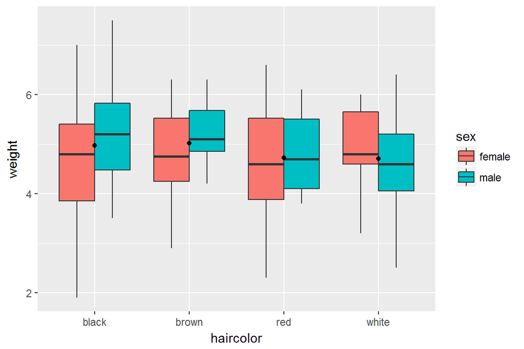

```r
p <- ggplot(catdata,aes(x=haircolor,y=weight)) +
  geom_boxplot(aes(fill=sex)) +
  stat_summary(fun.y=mean,
               geom="point")
plot(p)
```

On peut calculer une statistique sur les autres aesthetics. Ici par exemple on combien les groupes données par la variable haircolor et par la variable sex:

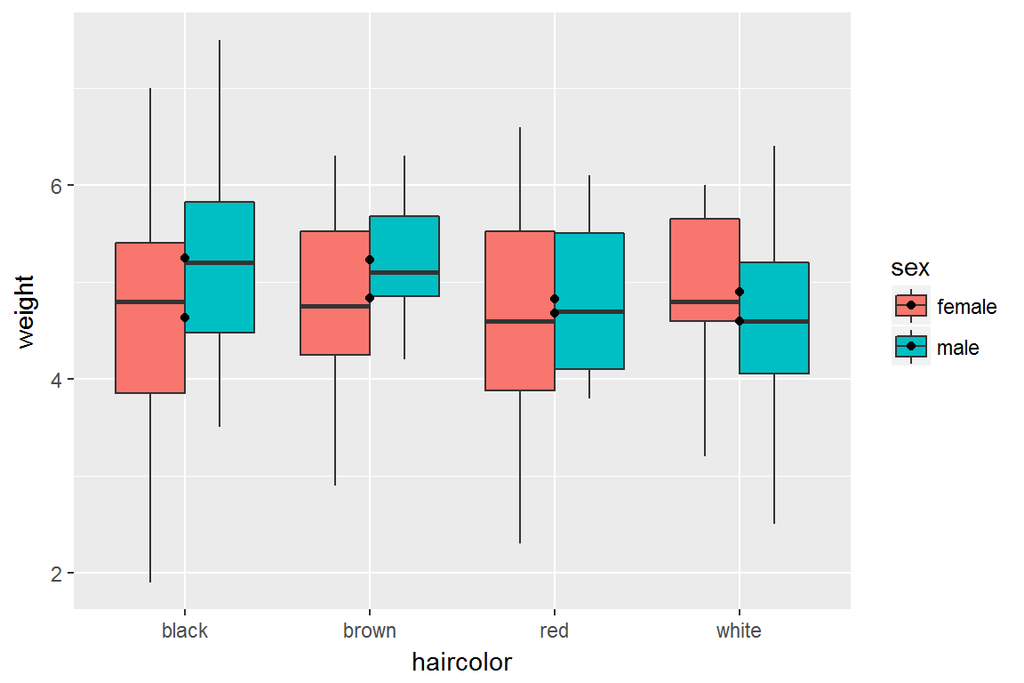

```r
p <- ggplot(catdata,aes(x=haircolor,y=weight)) +
  geom_boxplot(aes(fill=sex)) +
  stat_summary(fun.y=mean,
                     geom="point",
                     aes(fill=sex))
plot(p)
```

# Statistiques descriptives

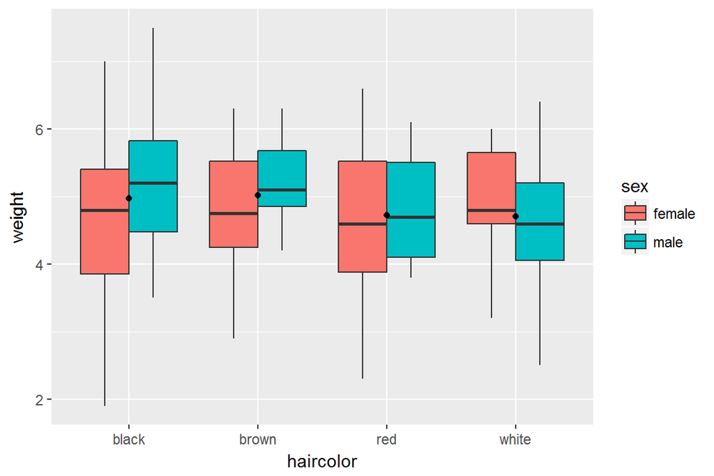

```r
p <- ggplot(catdata,aes(x=haircolor,y=weight)) +
  geom_boxplot(aes(fill=sex)) +
  stat_summary(fun.y=mean,
               geom="point")
plot(p)
```

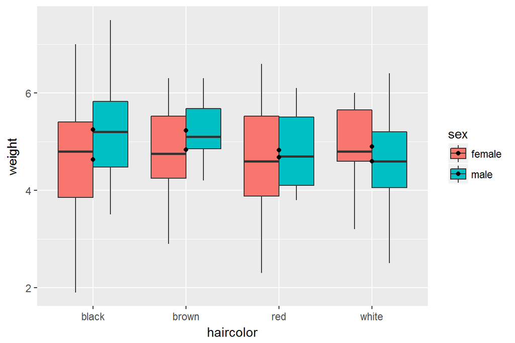

```r
p <- ggplot(catdata,aes(x=haircolor,y=weight,fill=sex)) +
  geom_boxplot() +
  stat_summary(fun.y=mean,
               geom="point")
plot(p)
```

# Statistiques descriptives

Pour ajuster la position (en x) des moyennes en fonction de sex on peut procéder comme suit:

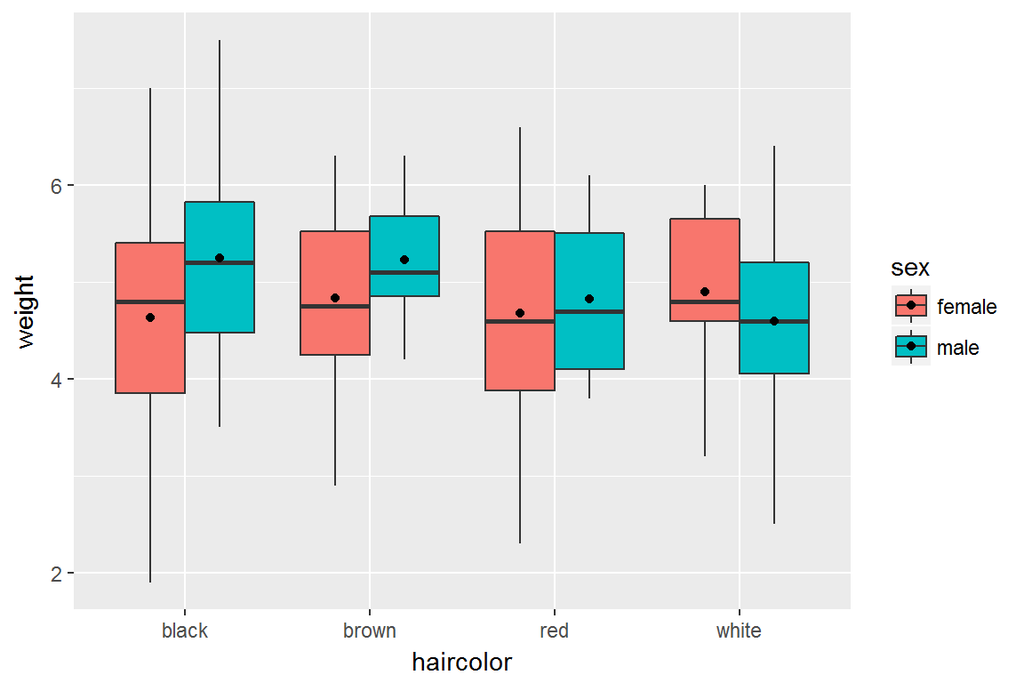

```r
p <- ggplot(catdata,aes(x=haircolor,y=weight)) +
  geom_boxplot(aes(fill=sex)) +
  stat_summary(fun.y=mean,
               geom="point",
               aes(fill=sex),
               position=position_dodge(width=0.75))
plot(p)
```

# Modèle de régression

Le package `ggplot2` offre aussi des possibilités intéressantes pour travailler sur le lien entre deux variables quantitatives (modèles de régression):

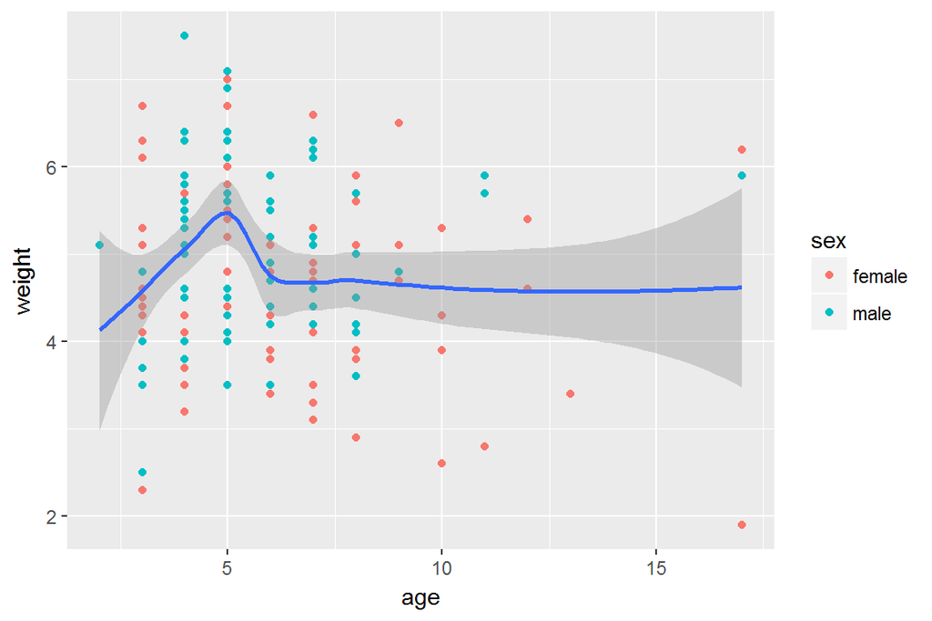

```r
p <- ggplot(catdata, aes(x=age,y=weight)) +
  geom_point(aes(col=sex)) +
  geom_smooth()
plot(p)
```

On ajoute une droite de régression avec la fonction `geom_smooth` (ici par défaut, régression de type loess). Allez voir le fichier d’aide associé à la fonction `geom_smooth` pour voir l’ensemble des paramètres de cette fonction…

Plus d’explications sur la régression loess [ici](http://perso.ens-lyon.fr/lise.vaudor/regression-loess/)

# Modèle de régression

On peut préciser le modèle en précisant des aesthetics supplémentaires:

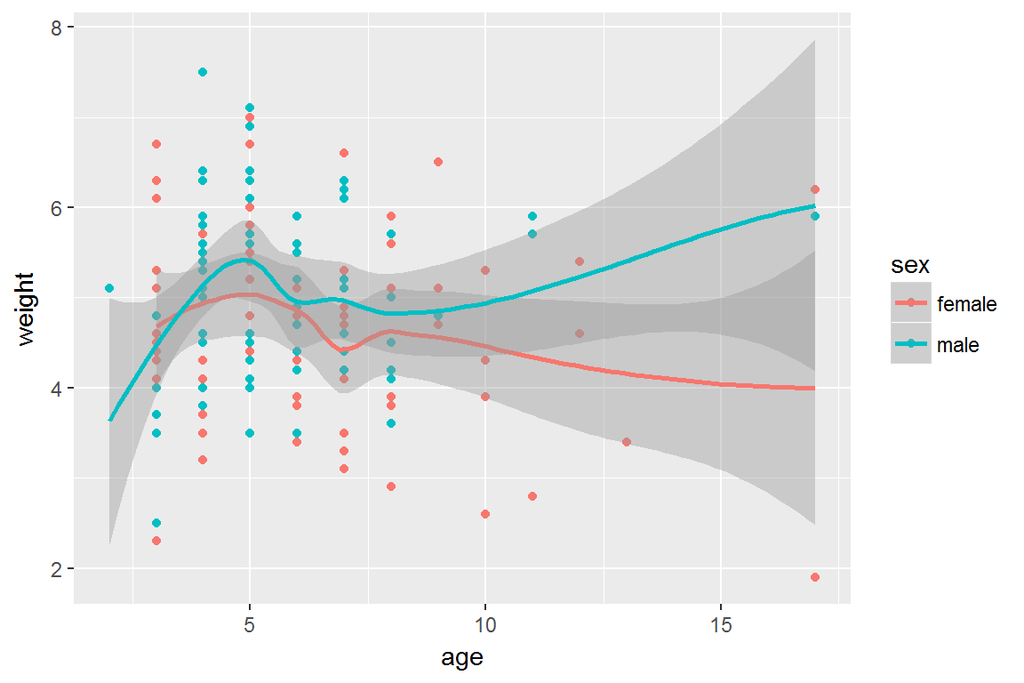

```r
p <- ggplot(catdata, aes(x=age,y=weight,col=sex)) +
  geom_point() +
  geom_smooth()
plot(p)
```

# Modèle de régression linéaire

Le type de régression réalisé est également paramétrable. Ici, par exemple, on réalise une régression linéaire:

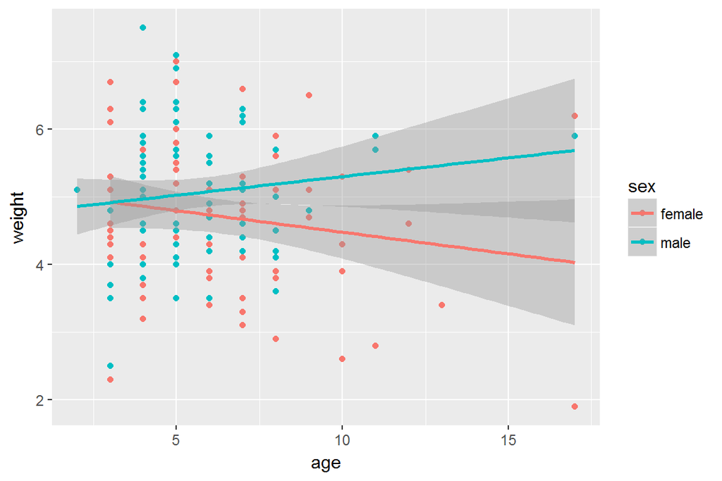

```r
p <- ggplot(catdata, aes(x=age,y=weight)) +
  geom_point(aes(col=sex))+
  geom_smooth(mapping=aes(col=sex),
              method="lm")
plot(p)
```

`ggplot2` permet de produire la **représentation graphique** du modèle de régression. Pour effectuer une régression et (par exemple récupérer ses coefficients), on passe par `lm()`:

```r
reg=lm(weight~age*sex, data=catdata)
summary(reg)
```

```
##
## Call:
## lm(formula = weight ~ age * sex, data = catdata)
##
## Residuals:
##      Min       1Q   Median       3Q      Max
## -2.62661 -0.72661  0.02871  0.62871  2.52863
##
## Coefficients:
##             Estimate Std. Error t value Pr(>|t|)
## (Intercept)  5.11809    0.28486  17.967   <2e-16 ***
## age         -0.06383    0.04007  -1.593   0.1133
## sexmale     -0.36767    0.42297  -0.869   0.3861
## age:sexmale  0.11906    0.06415   1.856   0.0654 .
## ---
## Signif. codes:  0 '***' 0.001 '**' 0.01 '*' 0.05 '.' 0.1 ' ' 1
##
## Residual standard error: 1.025 on 149 degrees of freedom
## Multiple R-squared:  0.0546, Adjusted R-squared:  0.03556
## F-statistic: 2.868 on 3 and 149 DF,  p-value: 0.03854
```